# Forest Removal

David Clark

July 3, 2016

In this project I investigate the relationship between forest removal and percent forest coverage for countries in the world. Forest removal is defined as the total value in US dollars of all products removed during that year. Products are both wood and non-wood related. All data is taken from the [Gapminder](https://www.gapminder.org/) website.

## Data Processing and Exploration

Let’s load the data and inspect it.

```r
forestCoverage = read.csv("data/forest_coverage.csv", header = TRUE)
forestRemoval = read.csv("data/forest_products_per_ha.csv", header = TRUE, na.strings = "")
```

Let’s view the column names:

```r
names(forestCoverage)
```

```
## [1] "Forest.coverage...." "X1990"               "X2000"
## [4] "X2005"               "X"                   "X.1"
## [7] "X.2"                 "X.3"                 "X.4"
```

```r
names(forestRemoval)
```

```
## [1] "Forest.products.per.ha..USD." "X2005"
## [3] "X"                            "X.1"
## [5] "X.2"                          "X.3"
## [7] "X.4"
```

I am only interested in the columns with data containing the country name and data for a specific year. Therefore, I am interested in columns 1 - 4 for `forerstCoverage` and columns 1 - 2 for `forestRemoval`.

```r
forestCoverage = forestCoverage[1:4]
forestRemoval = forestRemoval[1:2]
```

Let’s rename the columns so that they are more readable:

```r
colsForestCoverage = c("Country", "fc_1990", "fc_2000", "fc_2005")
colnames(forestCoverage) = colsForestCoverage

colsForestRemoval = c("Country", "fr_2005")
colnames(forestRemoval) = colsForestRemoval
```

In the `forestRemoval` data frame, the values in the `fr_2005` column are factors. I need to convert them to numeric, so that I can perform a linear regression fit:

```r
forestRemoval$fr_2005 = as.numeric(levels(forestRemoval$fr_2005))[forestRemoval$fr_2005]
```

Now, let’s view some metrics using `summary()`:

```r
summary(forestCoverage)
```

```
##            Country       fc_1990          fc_2000          fc_2005
##                : 10   Min.   :  0.03   Min.   :  0.03   Min.   :  0.03
##  Afghanistan   :  1   1st Qu.: 11.38   1st Qu.: 10.95   1st Qu.: 10.91
##  Albania       :  1   Median : 29.91   Median : 29.50   Median : 29.26
##  Algeria       :  1   Mean   : 33.01   Mean   : 32.21   Mean   : 31.80
##  American Samoa:  1   3rd Qu.: 49.50   3rd Qu.: 47.75   3rd Qu.: 46.79
##  Andorra       :  1   Max.   :100.00   Max.   :100.00   Max.   :100.00
##  (Other)       :224   NA's   :25       NA's   :25       NA's   :25
```

```r
summary(forestRemoval)
```

```
##            Country       fr_2005
##  Afghanistan   :  1   Min.   :  1.00
##  Albania       :  1   1st Qu.:  7.00
##  Algeria       :  1   Median : 26.00
##  American Samoa:  1   Mean   : 86.55
##  Andorra       :  1   3rd Qu.:115.00
##  (Other)       :224   Max.   :803.00
##  NA's          : 10   NA's   :138
```

You will notice that there are many points that are NAs These are missing data values and I want to remove them from the analysis. I do this with the following commands:

```r
forestCoverage = na.omit(forestCoverage)
forestRemoval = na.omit(forestRemoval)
```

Let’s look at a summary of the data again, but this time with out the NA values.

```r
summary(forestCoverage)
```

```
##            Country       fc_1990          fc_2000          fc_2005
##  Afghanistan   :  1   Min.   :  0.03   Min.   :  0.03   Min.   :  0.03
##  Albania       :  1   1st Qu.: 11.38   1st Qu.: 10.95   1st Qu.: 10.91
##  Algeria       :  1   Median : 29.91   Median : 29.50   Median : 29.26
##  American Samoa:  1   Mean   : 33.01   Mean   : 32.21   Mean   : 31.80
##  Andorra       :  1   3rd Qu.: 49.50   3rd Qu.: 47.75   3rd Qu.: 46.79
##  Angola        :  1   Max.   :100.00   Max.   :100.00   Max.   :100.00
##  (Other)       :208
```

```r
summary(forestRemoval)
```

```
##         Country      fr_2005
##  Afghanistan: 1   Min.   :  1.00
##  Albania    : 1   1st Qu.:  7.00
##  Algeria    : 1   Median : 26.00
##  Argentina  : 1   Mean   : 86.55
##  Armenia    : 1   3rd Qu.:115.00
##  Australia  : 1   Max.   :803.00
##  (Other)    :95
```

Since I am interested in the relationship between forest removal and forest coverage, I need to compare each dataframe equally. This means, I am only interested in countries that have data for both forest removal **and** forest coverage. To ensure this, I will merge the two dataframes into one dataframe using country to connect the two.

```r
forestMerged = merge(forestCoverage, forestRemoval, by='Country')
```

Now I attach the columns to the dataframe so I can reference the columns by column name:

```r
attach(forestMerged)
```

Before modeling the data, let’s use `ggplot` to make a scatterplot of forest removal versus forest coverage for the year 2005. This is the only year where data exists for both set’s of measurements.

```r
library(ggplot2)
```

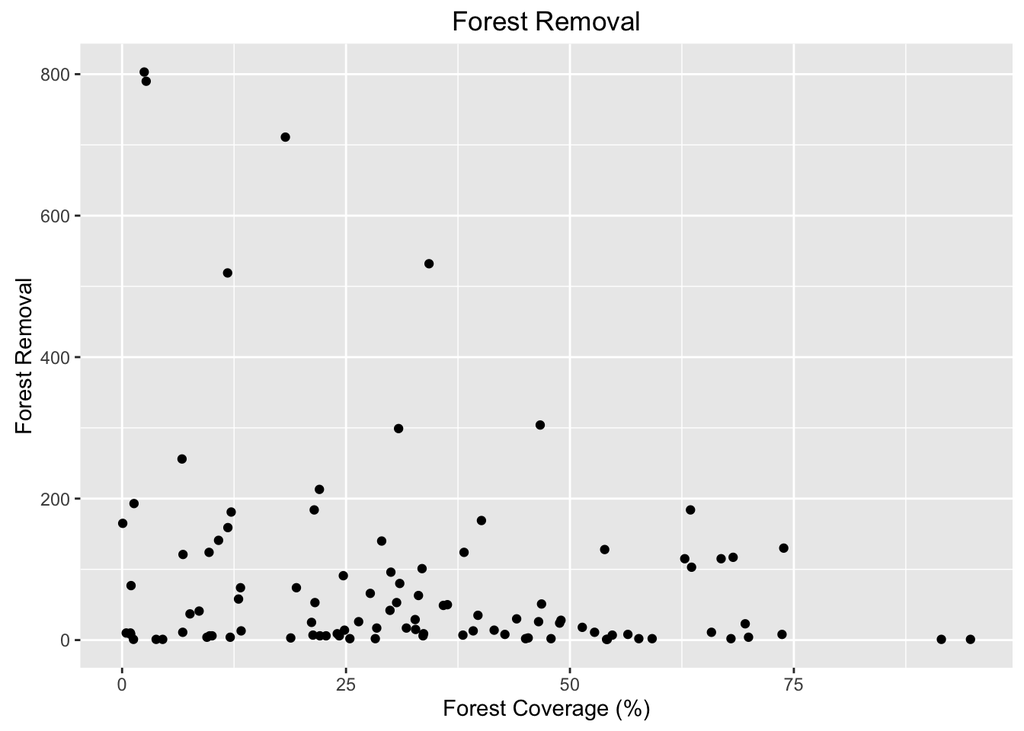

```r
ggplot(forestMerged, aes(x=fc_2005, y=fr_2005)) +
        labs(title = 'Forest Removal', x='Forest Coverage (%)', y='Forest Removal') +
        geom_point()
```

Right off you will notice a wide scatter. Specifically, there is a larger scatter in forest removal for low values of forest coverage.

## Linear Regression

Now I am ready to start modeling the data.

First, I fit a linear regression model to this dataset to see what is the relationship between forest coverage and forest removal.

```r
lm.fit = lm(fr_2005 ~ fc_2005, data=forestMerged)

coef(lm.fit)
```

```
## (Intercept)     fc_2005
##  138.678611   -1.604558
```

The negative coefficient for `fc_2005` indicates that there is an inverse relationship between forest coverage and forest removal.

Let’s look at the fit in more detail.

```r
summary(lm.fit)
```

```
##
## Call:
## lm(formula = fr_2005 ~ fc_2005, data = forestMerged)
##
## Residuals:
##     Min      1Q  Median      3Q     Max
## -135.64  -76.06  -39.93   16.06  668.28
##
## Coefficients:
##             Estimate Std. Error t value Pr(>|t|)
## (Intercept) 138.6786    26.5635   5.221 9.85e-07 ***
## fc_2005      -1.6046     0.6773  -2.369   0.0198 *
## ---
## Signif. codes:  0 '***' 0.001 '**' 0.01 '*' 0.05 '.' 0.1 ' ' 1
##
## Residual standard error: 149.6 on 99 degrees of freedom
## Multiple R-squared:  0.05366,    Adjusted R-squared:  0.0441
## F-statistic: 5.613 on 1 and 99 DF,  p-value: 0.01977
```

Can the model be improved by using a non-linear fit? Let’s take the log of forest removal and see how things change:

```r
lm.fit = lm(log(fr_2005) ~ fc_2005, data=forestMerged)
summary(lm.fit)
```

```
##
## Call:
## lm(formula = log(fr_2005) ~ fc_2005, data = forestMerged)
##
## Residuals:
##     Min      1Q  Median      3Q     Max
## -3.7361 -1.4395  0.1067  1.3487  3.1296
##
## Coefficients:
##              Estimate Std. Error t value Pr(>|t|)
## (Intercept)  3.758526   0.308261  12.193   <2e-16 ***
## fc_2005     -0.017635   0.007859  -2.244   0.0271 *
## ---
## Signif. codes:  0 '***' 0.001 '**' 0.01 '*' 0.05 '.' 0.1 ' ' 1
##
## Residual standard error: 1.736 on 99 degrees of freedom
## Multiple R-squared:  0.0484, Adjusted R-squared:  0.03879
## F-statistic: 5.035 on 1 and 99 DF,  p-value: 0.02707
```

To investigate this model fit further, let’s compute confidense intervals. This is done using the function `confint()`:

```r
confint(lm.fit)
```

```
##                  2.5 %       97.5 %
## (Intercept)  3.1468690  4.370183990
## fc_2005     -0.0332301 -0.002040822
```

We can also compute the confidense interval at several points using the `predict()` function. I choose the percent forest coverage values of 20, 40, 60, and 80:

```r
predict(lm.fit, data.frame(fc_2005=c(20, 40, 60, 80)), interval = 'confidence')
```

```
##        fit      lwr      upr
## 1 3.405817 3.011613 3.800021
## 2 3.053108 2.690861 3.415355
## 3 2.700399 2.151214 3.249583
## 4 2.347689 1.531272 3.164107
```

I now replot the scatter plot and add the regression line. I use `geom_smooth()` to add the regression line and include the confidense region on either side of the line.

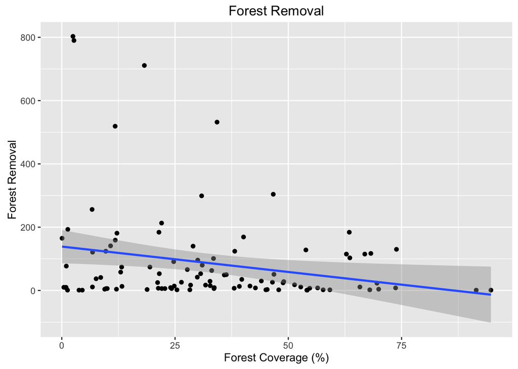

```r
ggplot(forestMerged, aes(x=fc_2005, y=fr_2005)) +
        labs(title = 'Forest Removal', x='Forest Coverage (%)', y='Forest Removal') +
        geom_point() +
        geom_smooth(method = lm)
```

Now we can graphically see that there is a downward trend in the model fit. This indicates that countries with more forest tend to remove less wood. But, why does this trend exist? Are there other factors that contribute to forest removal? To investigate, let’s add additional features and see how this affects the model fit.

## Adding Features

One reason countries with more forest might remove less wood is because they have a smaller population. Let’s add population as an additional feature and see what we find.

Load the data:

```r
population = read.csv('data/population.csv', header = TRUE)
attach(population)
```

Since I am only modeling data from 2005, I am only interested in the population for that year:

```r
population = population[c('Total.population', 'X2005')]
```

Rename the columns:

```r
colsPopulation = c("Country", "p_2005")
colnames(population) = colsPopulation
```

Merge population dataframe with `forestMerged` dataframe:

```r
forestPopMerged = merge(forestMerged, population, by="Country")
attach(forestPopMerged)
```

Performing a `summary()` on the `forestPopMerged` dataframe, we see that `p_2005` is of type other. We need to set this to a numeric value:

```r
forestPopMerged$p_2005 = as.numeric(levels(forestPopMerged$p_2005))[forestPopMerged$p_2005]
summary(forestPopMerged)
```

```
##         Country      fc_1990         fc_2000         fc_2005
##  Afghanistan: 1   Min.   : 0.04   Min.   : 0.06   Min.   : 0.07
##  Albania    : 1   1st Qu.:12.73   1st Qu.:12.94   1st Qu.:12.59
##  Algeria    : 1   Median :29.20   Median :29.67   Median :29.91
##  Argentina  : 1   Mean   :32.81   Mean   :31.83   Mean   :31.45
##  Armenia    : 1   3rd Qu.:50.62   3rd Qu.:47.23   3rd Qu.:45.92
##  Australia  : 1   Max.   :94.72   Max.   :94.72   Max.   :94.72
##  (Other)    :89
##     fr_2005        p_2005
##  Min.   :  1   Min.   :2.035e+05
##  1st Qu.:  7   1st Qu.:3.503e+06
##  Median : 26   Median :1.126e+07
##  Mean   : 84   Mean   :4.321e+07
##  3rd Qu.:109   3rd Qu.:3.327e+07
##  Max.   :803   Max.   :1.144e+09
##                NA's   :18
```

Remove NA values:

```r
forestPopMerged = na.omit(forestPopMerged)
summary(forestPopMerged)
```

```
##         Country      fc_1990         fc_2000         fc_2005
##  Afghanistan: 1   Min.   : 0.04   Min.   : 0.06   Min.   : 0.07
##  Albania    : 1   1st Qu.:12.58   1st Qu.:12.81   1st Qu.:12.18
##  Algeria    : 1   Median :30.07   Median :29.67   Median :30.01
##  Argentina  : 1   Mean   :33.34   Mean   :32.13   Mean   :31.67
##  Armenia    : 1   3rd Qu.:53.25   3rd Qu.:48.53   3rd Qu.:46.50
##  Bangladesh : 1   Max.   :94.72   Max.   :94.72   Max.   :94.72
##  (Other)    :71
##     fr_2005          p_2005
##  Min.   :  1.0   Min.   :2.035e+05
##  1st Qu.:  6.0   1st Qu.:3.503e+06
##  Median : 14.0   Median :1.126e+07
##  Mean   : 75.4   Mean   :4.321e+07
##  3rd Qu.: 91.0   3rd Qu.:3.327e+07
##  Max.   :803.0   Max.   :1.144e+09
##
```

Due to the merge, some points in the `forestMerged` dataframe have been removed. Let’s redo the model fit and see how it has changed:

```r
lm.fit = lm(fr_2005 ~ fc_2005, data=forestPopMerged)
summary(lm.fit)
```

```
##
## Call:
## lm(formula = fr_2005 ~ fc_2005, data = forestPopMerged)
##
## Residuals:
##     Min      1Q  Median      3Q     Max
## -134.05  -65.62  -24.60   17.34  670.30
##
## Coefficients:
##             Estimate Std. Error t value Pr(>|t|)
## (Intercept) 137.5413    29.1891   4.712  1.1e-05 ***
## fc_2005      -1.9619     0.7548  -2.599   0.0112 *
## ---
## Signif. codes:  0 '***' 0.001 '**' 0.01 '*' 0.05 '.' 0.1 ' ' 1
##
## Residual standard error: 147 on 75 degrees of freedom
## Multiple R-squared:  0.08263,    Adjusted R-squared:  0.0704
## F-statistic: 6.756 on 1 and 75 DF,  p-value: 0.01125
```

And `log(fr_2005)`…

```r
lm.fit = lm(log(fr_2005) ~ fc_2005, data=forestPopMerged)
summary(lm.fit)
```

```
##
## Call:
## lm(formula = log(fr_2005) ~ fc_2005, data = forestPopMerged)
##
## Residuals:
##     Min      1Q  Median      3Q     Max
## -3.7387 -1.4236 -0.0463  1.3388  3.2545
##
## Coefficients:
##              Estimate Std. Error t value Pr(>|t|)
## (Intercept)  3.770589   0.332720  11.333  < 2e-16 ***
## fc_2005     -0.025145   0.008604  -2.922  0.00459 **
## ---
## Signif. codes:  0 '***' 0.001 '**' 0.01 '*' 0.05 '.' 0.1 ' ' 1
##
## Residual standard error: 1.675 on 75 degrees of freedom
## Multiple R-squared:  0.1022, Adjusted R-squared:  0.09026
## F-statistic: 8.541 on 1 and 75 DF,  p-value: 0.004588
```

Yes, it did improve!

Let’s take a look at the plot.

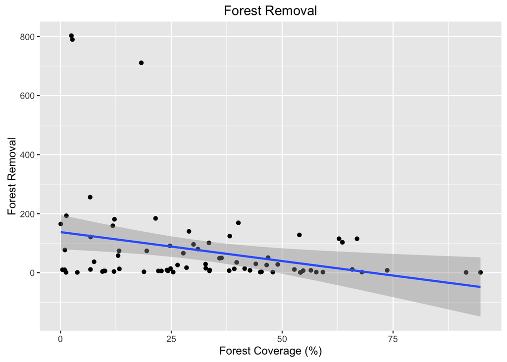

```r
ggplot(forestPopMerged, aes(x=fc_2005, y=fr_2005)) +
        labs(title = 'Forest Removal', x='Forest Coverage (%)', y='Forest Removal') +
        geom_point() +
        geom_smooth(method = 'lm')
```